# Projet d'optimisation : chauffage d'un bâtiment résidentiel

#### *Sebastian Partarrieu & Clement Desroches*

# I - Modélisation

### Question 1

En premier lieu, on cherche à effectuer un modèle plausible compte tenu des données fournies. Pour ce modèle, nous allons faire directement plusieurs hypothèses préliminaires:

- le chauffage est exclusivement électrique, c'est justifié ces dernières années.
- on suppose que l'énergie utilisée par la maison est exclusivement dûe au chauffage (c'est ce qu'on cherche à minimiser). Rajouter des sources de consommation d'énergies externes ne nous intéresse pas ici.

Ainsi la fonction à minimiser reste la facture d'électricité qui est uniquement reliée au chauffage pûrement effectué de manière électrique. On note $E_p$ ($E_c$) l'énergie consommée par la maison en heure pleine (creuse), $t_p$ ($t_c$) le tarif en heures pleines (creuses). On note M le montant à payer pour la consommation d'électricité.

Alors:

$M = E_c * t_c + E_p * t_p \tag{1}$

est la quantité que l'on sera amené à minimiser dans la deuxième partie de ce projet. Sa forme plus explicite ainsi que les contraintes associées seront détaillées une fois le modèle dynamique établi qui révelera les puissances mises en jeu à intégrer pour remonter aux énergies consommées.

### Question 2

Nous allons essayer de proposer un modèle de la température intérieure de la maison. Nous prenons donc comme système thermodynamique cet air à l'intérieur de la maison qui déterminera le confort des personnes à l'intérieur (en négligeant le fait que le confort thermique dépend de plusieurs facteurs, qui ne sont pas $T_{amb}$ la température ambiante de l'air, dont le métabolisme, les vêtements portés, l'humidité relative de l'air, la température des parois ou même la vitesse des mouvements d'air à l'intérieur de la maison).

```python
#Petite illustration des ordres de grandeur associés aux différentes sources de pertes thermiques
from IPython.display import Image
Image(url = 'https://www.mrcentralheating.co.uk/media/wysiwyg/houseHeat4.jpg', width = 300)
```

[figure not shown]

> Venons en donc aux différentes sources de transferts thermiques considérées ici qui sont :
> - le **chauffage intérieur** qui fournit une puissance $p_c(t)$
> - les **transferts thermiques à travers les murs** que l'on caractérise par un coefficient de perte $a$ qui sera déterminé par la suite. Si l'on suppose que la maison est un cube de coté l, et les murs sont d'épaisseur $e_{mur}$ et le plafond $e_p$. Pour un mur on obtient (On néglige la convection à l'intérieur de la maison) $R_{eq/mur} = \frac{1}{h*S_{mur}} + \frac{e_{mur}}{\lambda_{mur} * S_{mur}}$ avec $h$ le coefficient conducto-convectif qui caractérise les échanges de chaleur entre la paroi externe du mur et l'air.

>   Donc pour 4 murs (en parallèle) : $ R_{eq/ 4murs} = \frac{R_{eq/mur}}{4}$  
>   Pour le plafond : $R_{eq/p} = \frac{1}{h*S_{p}} + \frac{e_{p}}{\lambda_p * S_{p}}$ en considérant le même coefficient d'échange conducto-convectif que pour les murs (une hypothèse justifiée ci-dessous). Donc pour la maison en entier : $R_{eq/ maison} = (\frac{1}{R_{eq/p}} + \frac{1}{R_{eq/4murs}})^{-1}$

>   Alors on obtient finalement le coefficient de perte global de la maison qui caractérise les flux de chaleur à travers les parois:

>   $a = \frac{1}{R_{eq/maison}}, \Phi_{parois} = a*(T_{ext}(t)-T_{int}(t)) \tag{2}$
> - **rayonnement thermique** : $I_s(t) * S_{maison} * b$ (b étant un coefficient d'atténuation moyenné sur les quatres murs et le toit, $S_{maison}$ la surface extérieure de la maison et $I_s(t)$ le flux solaire moyenné sur les quatres murs et le toit) qui dépend de l'heure de la journée et donc du temps.

Les hypothèses effectuées sont donc:

- La maison est cubique
- On néglige les mouvements d'air à l'intérieur de la maison.
- On considère un même coefficient conducto-convectif entre les murs et l'air et le plafond et l'air. Concrètement, comme la nature du fluide et la température est la même dans les deux cas, ceci revient à considérer qu'il y a le même type d'écoulement au dessus du plafond et au niveau des parois.
- On néglige l'apport interne dû aux occupants, on considère donc une maison vide.
- On néglige la ventilation et les infiltrations d'air dans le bâtiment.
- On néglige les pertes par le sol, on fait l'hypothèse que le plancher est bien isolé et que la température du sol est proche de la température intérieure.
- Pour le rayonnement incident, en réalité il n'y que la surface *vitrée* sud qui laisse passer le rayonnement à l'intérieur, mais ici on fait une moyenne sur l'ensemble de la maison en considérant des parois semi-opaques caractérisées par ce coefficient d'atténuation
- En réalité, on a le flux solaire frappant une paroi qui se décompose en trois termes: le flux direct qui dépend de l'inclinaison et l'orientation des parois, le flux diffus (nuages), et le flux réfléchi par le sol et les autres parois. Ici on ne considère que le flux direct n'ayant pas accès aux conditions météo et ne pouvant pas décomposer le flux incident en cette somme de termes plus précis.

Finalement l'équation qui régit la dynamique de température de l'air à l'intérieur de la maison est:

$\boxed{C_{air}*\frac{\partial{T_{int}(t)}}{\partial{t}} = a*(T_{ext}(t)-T_{int}(t)) + p_c(t) + I_s(t) * S * b} \tag{3} $

où $C_{air}$ est la capacité thermique de l'air à l'intérieur de la maison.

### Question 3

#### Visualisation des données

Avant de discrétiser la dynamique et de proposer une méthodologie d'identification, on représente les données fournies pour appréhender correctement le problème.

```python
import numpy as np
import matplotlib.pyplot as plt
from scipy import stats, optimize
import pandas as pd
import time
```

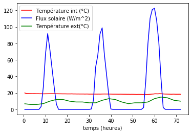

```python
#visualisation des données
df = pd.read_csv('donnees-projet-gr4.txt', header = None,  delimiter='\t')
T, Y1, Y2, Y3 = np.array(df[0]), np.array(df[1]), np.array(df[2]), np.array(df[3])
plt.xlabel('temps (heures)')
plt.plot(T, Y1, c='r', label = 'Température int (°C)')
plt.plot(T, Y2, c='b', label = 'Flux solaire (W/m^2)')
plt.plot(T, Y3, c='g', label = 'Température ext(°C)')
plt.legend(loc='upper left')
plt.show()
```

On observe donc l'évolution de certains paramètres du problème sur une durée de trois jours. Les grandeurs physiques sont échantillonées toutes les demi-heures. On voit directement que la température à l'intérieur de la maison reste presque constante au cours du temps, **sans chauffage a priori** ce qui nous amènera à éliminer le terme $p_c(t)$ dans l'équation (3). On sera amené à considérer des températures extérieures différentes ainsi que des autres niveaux de confort demandé à l'intérieur (température intérieure) plus tard dans le sujet.

Pour l'instant, **reprenons l'équation décrite précedemment** sans terme de chauffage,

$$C_{air}*\frac{\partial{T_{int}(t)}}{\partial{t}} = a*(T_{ext}(t)-T_{int}(t)) + I_s(t) * S_{maison} * b \tag{4}$$

On a $C_{air} = c_{air}V_{maison}$ avec $c_{air} = 1,256 kJ.m^{-3}.K^{-1}$ la capacité thermique volumique de l'air. D'après le modèle précédent, on a $V_{maison} = l^3$ avec $l$ le côté du carré qui modélise les murs et le plafond de la maison.

On connaît l'évolution de $T_{int}(t)$, $T_{ext}(t)$ et $I_s(t)$. Il s'agit donc d'identifier les paramètres $S_{maison} = 5*l^2$, $a$, $b$ et $V_{maison} = l^3$. Finalement, il s'agit d'identifier $l$, $a$ et $b$, suivant la méthode décrite prochainement.

On note simplement à ce stade qu'on peut mettre (4) sous la forme d'une équation différentielle du premier ordre sur $T_{int}$ avec des coefficients constants mais un second membre non constant. La solution explicite de l'équation homogène associée est directe, sous la forme: $$T_{int}^{H}(t) = e^{-\frac{a}{C_{air}}*t}$$ La solution particulière se trouve avec la méthode de "variation de la constante", cependant ce n'est pas intéressant de faire la résolution analytique ici. On préférera implémenter directement une résolution numérique de l'équation différentielle: $$y' = f(t,y,a,b,l) \tag{5}$$

#### Identification des constantes et discrétisation de la dynamique

*Explication de la démarche*: Prenons l'équation (5), on va trouver avec l'aide d'un bon vieux Euler codé à la main, la fonction $T_{int}$ solution de l'équation. Implémenter un Runge-Kutta ou un solveur ODE dédié est plus difficile car on a pas accès aux fonctions continues qu'on pourrait évaluer en n'importe quel point mais à des données déjà discrétisées.

On aura donc N = 144 points de température avant de procéder à une pénalisation des moindres carrés et un algorithme des moindres carrés non linéaire, qui est donc soit Gauss-Newton ou Levenberg-Marquardt. Ici on pourra utiliser des algorithmes de scipy.optimize comme curve_fit ou least_squares pour implémenter ces algorithmes.

Procédons ainsi à la résolution numérique de l'équation différentielle (5) en dicrétisant le tout et en approximant l'intégrale avec la méthode des rectangles à gauche. Cela donne : $$C_{air}*(T_{int}^{i+1}) = \Delta t * a *T_{ext}^{i}+T_{int}^{i}(C_{air} - \Delta t * a) + I_s^{i} * S_{maison} * b*\Delta t$$

et finalement, en remplacant a par a' (on note a' par a dans le code par simplicité) une résistance surfacique (de sorte à éliminer la dépendance entre a et l qui amène à des résultats abhérents en tournant nos algorithmes d'optimisation), telle que $a' = \frac{a}{5 l^2}$.

```python
def myfunc(Tint, i, a, b, l):
    '''
    Renvoie l'itération suivante, le T_{int}^{i+1},pour une méthode d'Euler en utilisant un rectangle à gauche pour approximer
    l'intégrale. Il est plus aisé de donner i l'indice dans la discrétisation que le temps.
    En se rappelant que pour les données extraites, T est le temps, Y1 Tint, Y2 le flux solaire
    et Y3 Text. On rappelle que c_{air}, la capacité thermique volumique de l'air 1256 J.m-3.K-1 et que le pas de temps est
    fixé par nos donnée et vaut une demi-heure, soit 1800s.
    '''
    pas_temps = 1800.0
    cair = 1256.0
    alpha = (pas_temps*a*3)/(cair*(l))
    return alpha*(Y3[i] - Tint) + Tint + (3*b*pas_temps/(cair*l))*Y2[i]
```

```python
def Euler_explicit(func, a, b, l, shift=0):
    '''
    Implémente Euler explicite. Vu que la plupart des paramètres sont fixés par notre discrétisation prélable, on a pas besoin
    de préciser le nombre de points ou la condition initiale dans les arguments.
    '''
    y0 = Y1[shift]
    T_int = [y0]
    for i in range(1, 144-shift):
        T_int.append(func(T_int[i-1], i-1+shift, a, b, l))
    return np.array(T_int)
```

```python
shift = 2
def penalisation(X):
    T_int_1 = Euler_explicit(myfunc, X[0], X[1], X[2], shift)
    T_int_reel = Y1[shift:]
    return np.array([np.sum((T_int_1 - T_int_reel)**2) for _ in range(3)]) #Pour avoir un vecteur de taille 3 en sortie
```

```python
Result = optimize.least_squares(penalisation, np.array([0.001, 0.001, 1]), method='lm')
a_1 = Result.x
print(a_1, Result.cost)
```

```
[4.54421975e-04 1.26231136e-04 1.00000130e+00] 8.803128054277593
```

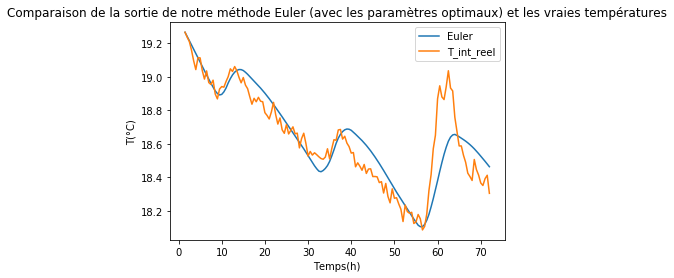

```python
plt.plot(T[shift:], Euler_explicit(myfunc, a_1[0], a_1[1], a_1[2], shift), label="Euler")
plt.plot(T[shift:], Y1[shift:], label="T_int_reel")
plt.xlabel("Temps(h)")
plt.ylabel("T(°C)")
plt.legend(loc='upper right')
plt.title('Comparaison de la sortie de notre méthode Euler (avec les paramètres optimaux) et les vraies températures')
plt.show()
```

On procède ainsi à une méthode similaire à celle présentée en annexe, on réinitialise à chaque pas la valeur de $T_{int}$ de sorte à considérer non pas une erreur cumulée mais une erreur locale sur chaque point de la discrétisation.

```python
def myfunc2(Tint, i, a, b, l):
    '''
    Calcul du pas suivant sans accumulation de l'erreur.
    '''
    pas_temps = 1800.0
    cair = 1256.0
    alpha = (pas_temps*a*3)/(cair*l)
    return alpha*(Y3[i]) + (1 - alpha)*(Y1[i]) + (b*3*1800/(cair*l))*Y2[i]

def penalisation2(X):
    T_int_1 = Euler_explicit(myfunc2, X[0], X[1], X[2])
    T_int_reel = Y1
    return np.array([np.sum((T_int_1 - T_int_reel)**2) for _ in range(3)])

Result2 = optimize.least_squares(penalisation2, np.array([1, .001, 8]), method='lm')
a2 = Result2.x
print(f'a2 = {a2[0]}, b2 = {a2[1]}, l2 = {a2[2]}, cost = {Result2.cost}')
```

```
a2 = 0.010533578820845952, b2 = 0.002629503624724889, l2 = 16.008637909788444, cost = 0.6333936261809612
```

```python
#Paramètres trouvés avec d'autres conditions initiales très différentes
Result3 = optimize.least_squares(penalisation2, np.array([1, .01, 1]), method='lm')
a3 = Result3.x
print(f'a3 = {a3[0]}, b3 = {a3[1]}, l3 = {a3[2]}, cost = {Result3.cost}')
```

```
a3 = 0.001860947934635013, b3 = 0.0004645376948276665, l3 = 2.828103395074642, cost = 0.6333936302133456
```

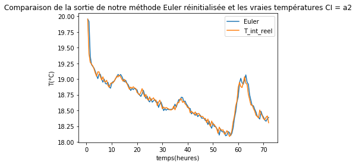

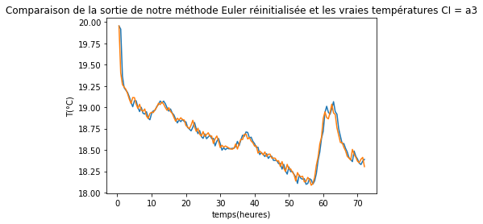

```python
plt.plot(T, Euler_explicit(myfunc2, a2[0], a2[1], a2[2]), label="Euler")
plt.plot(T, Y1, label="T_int_reel")
plt.xlabel("temps(heures)")
plt.ylabel("T(°C)")
plt.legend(loc='upper right')
plt.title('Comparaison de la sortie de notre méthode Euler réinitialisée et les vraies températures CI = a2')
plt.show()
plt.plot(T, Euler_explicit(myfunc2, a3[0], a3[1], a3[2]), label="Euler")
plt.plot(T, Y1, label="T_int_reel")
plt.xlabel("temps(heures)")
plt.ylabel("T(°C)")
plt.title('Comparaison de la sortie de notre méthode Euler réinitialisée et les vraies températures CI = a3')
plt.show()
```

**Conclusion** On a donc implémenté un "Euler réinitialisé", en fait en considère juste l'erreur locale à chaque pas de la discrétisation et on cherche à minimiser l'écart entre ces erreurs et $T_{int}$ donnée à travers le choix des paramètres a , b et l. On voit que cette méthode aboutit sur des résultats *beaucoup* plus cohérents. Notre maison est de l'ordre de $100 m^2$ ce qui est plutôt cohérent (même si avec 10m de hauteur c'est plutôt un immeuble :) ). Le paramètre a' est de l'ordre de $0,005 W.K^{-1}.m^{-2}$, d'où $a = 2,5 W.K^{-1}$ ce qui se traduit en une résistance thermique $R_{eq/maison} = 0.4 K.W^{-1}$. Finalement le paramètre b est de l'ordre de $0.0010$ ce qui semble très logique vu qu'on a effectué une moyenne d'un coefficient d'atténuation sur l'ensemble de la maison. Cet ordre de grandeur ne fait que traduire qu'il existe une grande surface de parois opaques qui ne laissent rentrer que très peu de lumière.

### Question 4

Nous avons donc déterminé les trois constantes a, b et l. Nous ne pouvons pas contrôler $I_{s}(t)$ ni $T_{ext}(t)$ et il s'agit de contrôler $T_{int}(t)$ à travers la consommation électrique (chauffage).

Le problème d'optimisation est donc maintenant de minimiser la consommation électrique de la maison, liée à la puissance, elle même liée à d'autres paramètres physiques déterminés précédemments:

$ p_c(t) = C_{air}*\frac{\partial{T_{int}(t)}}{\partial{t}} - I_s(t) * S * b - a*(T_{ext}(t)-T_{int}(t)) \tag{6} $

D'après EDF les heures creuses sont limitées à 8h maximum par jour, nous choisissons une plage d'heures creuses de 00h00 à 8h du matin.

Donc $E_c = \int_{0}^{8h}p_c(t)dt$ et de même $E_p = \int_{8h}^{24h}p_c(t)dt$

Finalement cela nous donne la fonction objective à minimiser qui est une fonction d'un profil de puissance à travers la journée (c'est à dire de $t \rightarrow p_{c}(t)$ pour $t \in [0, 24hr]$ (variable de décision)):

$$f(p_c(t)) = \int_{0}^{8h}p_c(t)dt*t_{c} + \int_{8h}^{24h}p_c(t)dt*t_{p} \tag{7}$$

avec $t_c$ et $t_p$ les tarifs en heures creuses et pleines.

En suivant la même démarche de discrétisation que pour la question 3, la variable de décision est un vecteur de $\Re ^{N}$ où N = 144, le nombre de points de discrétisation, qui contient les $p_i$ puissance instantanée en $t_i$. Ainsi notre fonction objective n'est plus (7) mais est donc (comme on prend 8 heures et que les données commencent à minuit): $$X = \begin{pmatrix}{p_1\\ \vdots \\p_N} \end{pmatrix}, \boxed{ f(X) = \sum_{i = 1}^{\lfloor\frac{N}{3} \rfloor}p_{i}*\Delta t*t_c + \sum_{i = \lfloor\frac{N}{3} \rfloor + 1}^{N}p_{i}*\Delta t*t_p} \tag{8}$$

Les contraintes sont au nombre de 5 :

- La température intérieure doit rester entre deux températures limites, déterminées par les habitants. C'est donc deux contraintes inégalités. $T_{min} \leq T_{int} \leq T_{max} \tag{9}$
- La puissance doit rester entre 0 et une puissance nominale maximale. C'est aussi deux contraintes inégalités. $0 \leq p_i \leq p_{max} \tag{10}$

La dernière contrainte est un peu plus longue à détailler, elle découle de l'équation (6) discrétisée et de nos contraintes sur la température. On a, en discrétisant (différences finies pour le terme dérivé)(6): $$p_c^{i} = C_{air} * \frac{T_{int}^{i+1} - T_{int}^{i}}{\Delta t} - I_s^{i} * S * b - a*(T_{ext}^{i}-T_{int}^{i}) \tag{11}$$ et donc en combinant (11) avec (9) (tous nos coefficients sont positifs) on obtient: $$ C_{air}*\frac{T_{min} - T_{max}}{\Delta t} - I_s^{i} * S * b - a*T_{ext}^{i} + a*T_{min} \leq p_c^{i} \leq C_{air}*\frac{T_{max} - T_{min}}{\Delta t} - I_s^{i} * S * b - a*T_{ext}^{i} + a*T_{max}$$ Or le terme de gauche est toujours inférieur à 0 (vérifier rapidement avec les ordres de grandeur des données). Finalement : $$p_c^{i} \leq C_{air}*\frac{T_{max} - T_{min}}{\Delta t} - I_s^{i} * S * b - a*T_{ext}^{i} + a*T_{max}\tag{12}$$ est la dernière contrainte, sous la forme d'un vecteur portant sur chaque $p_i$ et n'est donc pas redondante avec la contrainte inégalité entre pi et pmax.

### Des éléments de correction

- C'est mieux de rajouter le rendement devant le terme lié à la puissance
- Enlever la première donnée aurait amené à de meilleurs résultats
- S est pris comme $3l^2$ dans la correction et non $5l^2$ ce qui est logique pour le terme de flux reçu par la maison
- Les valeurs du corrigé: $l = 2.379m$, $R_{eq} = 45.454K/W$, $b = 3.789.10^{-4}$. **On continuera cependant dans la suite du projet à utiliser nos valeurs trouvées par Euler avec un terme de shift car elles permettent une comparaison et une validation des algorithmes de minimisation sous contraintes**
- Il faut faire attention a la définition des constantes pour lors de l'implémentation de la fonction scipy least squares, ne pas laisser des paramètres au dénominateur!!
- Juste laisser un vecteur de coût sans essayer de décomposer heures pleines, heures creuses (d'autant plus que les N points sont sur 3 jours, 72 heures, donc la décomposition en 3 segments de 8 heures n'est pas correcte).
- Pas besoin de traduire la contrainte dynamique en une contrainte inégalité comme fait dans l'équation (12). Surtout que il n'y a pas équivalence entre (11) et (12) c'est une chaîne d'implications.

# II - Etude et résolution numérique

## Question 1

Il s'agit d'étudier le problème, sa convexité, son conditionnement et l'existence et unicité d'une solution. Reprennons ainsi la formulation conseillée du problème de minimisation dans la correction de la première partie.

$$\min_{P, T_{int}} \Delta t \sum_{k=1}^{N}c_{k}p_{k}$$$$\forall k, T_{int}^{k+1} = g_{k}(T_{int}^{k}, p_{k}) \tag{i}$$$$\forall k, 0\leq p_{k} \leq p_{max} \tag{ii}$$$$\forall k, T_{min} \leq T_{int}^{k} \leq T_{max} \tag{iii}$$

**Convexité**

On a le vecteur $\begin{pmatrix}{c_1\\ \vdots \\c_N} \end{pmatrix}, \forall k\in [1, N], c_{k} \in \{c_{creuses}, c_{pleines}\} $, fixé. On réécrit donc la fonction objective à minimiser comme $f(P, T) = \Delta t c^{T} P$ avec $P = \begin{pmatrix}{p_1\\ \vdots \\p_N} \end{pmatrix}$. On a, en prennant N points de puissance et N+1 points de température intérieure, $f: \Re^{N}_{+}x \Re^{N+1}_{+} \longrightarrow \Re$, qui est une fonction linéaire et donc clairement convexe. Il faut ensuite regarder les contraintes du problème.

On reformule la contrainte (ii) comme étant $\left\|{P}\right\|_{\infty} \leq p_{max}$ (on n'a pas besoin de spécifier la positivité de P dans la contrainte car on prend f défini sur $\Re^{N}_{+}x \Re^{N+1}_{+}$). Par inégalité triangulaire sur la norme, cette contrainte est convexe. (Sinon chaque composante est linéaire donc ça marche).

La (double) contrainte (iii) n'a aussi que des composantes linéaires et donc convexes.

(13) est clairement linéaire en $(T_{int}^{k}, p_{k})$ avec des coefficients constants déterminés dans la partie I de ce notebook devant chacun de ces termes. La convexité s'en suit. Le problème est donc effectivement convexe.

**Existence et unicité d'une solution**

Le problème est convexe. La fonction objective est linéaire et donc différentiable. On a, sur le domaine de définition qui est $\Re^{N}_{+}x \Re^{N+1}_{+}$, le minimum de la fonction f vaut 0 et il est atteint en un point unique (en prenant $\forall k, 0 \leq c_k$, i.e on ne gagne pas de l'argent en consommant de l'électricité) $\begin{pmatrix}{0 \\ \vdots \\ 0}\end{pmatrix}$. Ceci est logique, pour minimiser la fonction coût sans contrainte, il suffit de ne jamais injecter de la puissance électrique dans ma maison et je ne paierai rien en électricité.

Pour étudier l'existence d'un minimum **sous les contraintes** envisagées on pourrait regarder si les conditions de KKT sont satisfaites en un point régulier et comme le problème est convexe ceci me donnerait l'existence du minimum global. Cependant, analytiquement cette approche ne nous aide pas énormément car on ne sait pas quelles contraintes sont actives. On remarque plutôt qu'on a un problème de minimisation d'une fonction linéaire sous des contraintes linéaires, on a donc l'existence d'un minimum à notre problème. Il n'y a aucune raison de penser à priori que notre minimum est unique car la fonction n'est pas $\alpha$ convexe.

**Méthode de résolution**

Pour la résolution de notre problème, nous allons procéder de la même façon que dans les TP en implémentant un algorithme de Arrow-Hurwitcz. On implémentera aussi la méthode minimize de scipy pour pouvoir comparer nos résultats avec une méthode de minimisation ultra performante. On pourrait, avec du temps en plus, implémenter un algorithme des contraintes actives qui semble intéressant à première vue sachant que l'on ne sait pas quand les différentes contraintes s'activent et c'est là tout l'enjeu.

On va donc commencer par reformuler le problème, de sorte à n'avoir que des contraintes inégalités, en substituant la contrainte égalité (i) dans l'expression de notre fontion objective et de nos autres contraintes. On a: $$\forall i\in \{1,...,N\}, p_c^{i} = \frac{1}{r}(C_{air} * \frac{T_{int}^{i+1} - T_{int}^{i}}{\Delta t} - I_s^{i} * S * b - a*(T_{ext}^{i}-T_{int}^{i}))$$ On considère r = 1 pour simplifier l'écriture de nos expressions (on ne l'oubliera pas lors de l'implémentation des algorithmes). Une fois que l'on aura minimisé le problème équivalent on pourra toujours remonter à l'expression de notre P optimal avec l'égalité ci-dessous.

D'où en passant ceci sous forme matricielle $P = AT - S*bI_{s} - aT_{ext}$

avec $ A\in M_{N, N+1}(\Re), A = \begin{pmatrix} (a-\frac{C_{air}}{\Delta t}) & \frac{C_{air}}{\Delta t} & 0 & \cdots & 0 & 0\\ 0 & (a-\frac{C_{air}}{\Delta t}) & \frac{C_{air}}{\Delta t} & 0 & \vdots & \vdots\\ \vdots & \vdots &\ddots & \ddots & \frac{C_{air}}{\Delta t} & 0\\ 0 & \cdots & \cdots &0 & (a-\frac{C_{air}}{\Delta t})&\frac{C_{air}}{\Delta t} \end{pmatrix}$, $T \in \Re^{N+1}$ et $I_{s}, T_{ext}$ les vecteurs dans $\Re^{N}$ du flux solaire et de la température extérieure.

La contrainte (ii) se reformule également à l'aide de cette nouvelle expression de P. Il ne faut pas oublier de **remettre la contrainte de positivité** sur P vu que ce n'est plus une variable prise dans un domaine de définition donnant directement sa positivité. On a, après avoir réécrit les contraintes, le lagrangien du problème reformulé:

$$L(T, \lambda) = \Delta t c^{T}(AT - SbI_{s} - aT_{ext}) + \lambda_{1}^{T}(-AT + SbI_{s} + aT_{ext}) + \lambda_{2}^{T}(AT - SbI_{s} - aT_{ext} - P_{max})+ \lambda_{3}^{T}(T-T_{max}) + \lambda_{4}^{T}(T_{min}-T) \tag{14}$$

où $\lambda_1, \lambda_2, \lambda_3, \lambda_{4}$ sont des vecteurs qui composent $\lambda$ et $P_{max}, T_{max}, T_{min}$ les vecteurs composés de leurs valeurs respectives. Remarquons à ce stade qu'il serait intéressant de rajouter une contrainte de **condition initiale** de température, ce qui simulerait la minimisation de coût lorsque l'utilisateur décide à un moment donné d'allumer son chauffage. En effet, on verra que les algorithmes de minimisation choisiront toujours la condition initiale vers Tmax de sorte à laiser agir la dynamique de refroidissement du système sans devoir injecter de la puissance. On note finalement que l'on est pas obligé de prendre N = 144.

## Question 2

On commence par proposer $r = 1$, cette fois non par soucis de simplification des équations, mais parce que un chauffage électrique fonctionne par effet joule et ainsi convertit toute l'énergie qu'il reçoit en chaleur. Comme on l'avait précisé dans la partie I, EDF fixe 8 heures creuses au maximum dans la journée. On prend ces heures creuses de 00:00 à 08:00 avec des tarifs de $tarif_{creuses} = 0,1337€/kWh$, $tarif_{pleines} = 0,1781 €/kWh$ (tarifs mis à jour en avril 2020 d'EDF). Vu qu'on travaille avec des tranches de demi-heures, il en vient que les composantes de notre vecteur coût sont composées de $c_{creuses} = \frac{0,1337}{2} = 0,06685 €/kW\Delta t$, $c_{pleines} = \frac{0,1781}{2} = 0,08905 €/kW\Delta t$. On met en place en premier lieu l'algorithme d'Arrow-Hurwicz pour résoudre notre problème.

#### Posons les constantes utiles

```python
#On définit tous les paramètres utiles, en global car toutes nos fonctions vont les utiliser
l = a_1[2]            #m
a = a_1[0]*3*a_1[2]**2      #W/K  on rapelle que le a trouvé en I était surfacique
b = a_1[1]    #sans unité
c_creuses = 0.06685*10**(-3)  #€/(W*pas_temps)
c_pleines = 0.08905*10**(-3)  #€/(W*pas_temps)
pas_temps = 1800.0    #s
S = 3*l**2            #m^2
T_ext = Y3[2:-1]        #°C mais ça se compense
Is = Y2[2:-1]           #W/m^2
Tmax = 22
Tmin = 18
Pmax = 750 #Source sur internet que 750 W pour une pièce de 25 m^3 ce qui est largement plus grand que celle envisagée
c_air = 1256.0        #J.m-3.K-1
cout = []
for _ in range(3):
    for _ in range(16):
        cout.append(c_creuses)
    for _ in range(32):
        cout.append(c_pleines)
cout = np.array(cout)[2:-1] #Pour avoir N=141 points
N = len(cout)
T_max = np.array([Tmax for _ in range(N+1)]) #N+1 car même taille que le vecteur de Tint
T_min = np.array([Tmin for _ in range(N+1)]) #idem
P_max = np.array([Pmax for _ in range(N)])   # même taille que Text et Is
print(N)#on a bien 141 points de coûts
A = np.array([[a - (c_air*l**3)/pas_temps if i==j else (c_air*l**3)/pas_temps if j==i+1 else 0 for j in range(N+1)] for i in range(N)])
```

```
141
```

#### Définissons les fonctions utiles

```python
def P(T):
    return np.matmul(A, T) - S*b*Is - a*T_ext

def fun(T):
    '''
    T de taille N+1, en K. T en numpy array
    '''
    return pas_temps*np.dot(cout, np.matmul(A, T) - S*b*Is - a*T_ext)

def grad_fun(T):
    return pas_temps*np.matmul(A.transpose(), cout)

def contrainte(T, P_max = P_max, T_max = T_max, T_min = T_min):
    '''
    Vecteur de contrainte. Taille 4N + 2. T en K et numpy array
    '''
    C1, C2, C3, C4 = P(T), P_max - P(T), T_max - T , T - T_min
    C = np.concatenate((C1, C2, C3, C4))
    return C  #SLSQP demande des contraintes positives

def grad_contrainte(T):
    '''
    C'est une matrice de taille 4N+2, N+1
    '''
    G1, G2, G3, G4 = A, -A, -np.eye(N+1, N+1), np.eye(N+1, N+1)
    G = np.concatenate((G1, G2, G3, G4))
    return G
```

#### Et on teste

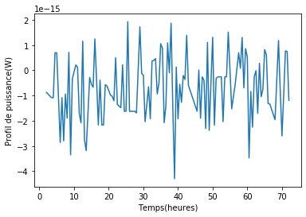

```
'Le coût est de -1.4874064636211102e-14 €'
```

```python
#Vérification que la fonction coût renvoi 0 pour le profil de température trouvé par Euler dans la partie I
plt.plot(T[3:], P(Euler_explicit(myfunc, a_1[0], a_1[1], a_1[2], 2)))
plt.xlabel('Temps(heures)')
plt.ylabel('Profil de puissance(W)')
plt.show()
f'Le coût est de {fun(Euler_explicit(myfunc, a_1[0], a_1[1], a_1[2], 2))} €'
```

C'est plutôt rassurant, aux erreurs d'approximation numérique près, le profil de puissance pour le profil de température trouvé en I (c'est à dire sans puissance électrique utilisée dans la maison) est quasi-nulle. La fonction coût également!

#### Venons en à l'optimisation proprement dite

On commence avec du arrow-hurwitcz avec un pas constant (le pas choisi avec wolfe allonge le temps d'exécution pour des résultats pas forcément meilleurs, en tout cas lorsque testé avec l'implémentation de Wolfe du TP).

```python
def arrow_hurwicz(fun, grad_fun, contrainte, grad_contrainte, x0, l, rho, lambda0 = np.array([0.1 for _ in range(4*N+2)]), max_iter = 10000, epsilon_grad_L = 1e-4):
    compteur = 0
    xk = x0
    lamb_k = lambda0
    grad_lagrang = 1
    while compteur <= max_iter and np.linalg.norm(grad_lagrang) >= epsilon_grad_L:
        grad_lagrang = grad_fun(xk) + np.matmul(lamb_k, grad_contrainte(xk))
        pk = -grad_lagrang
        xk1 = xk + l*pk
        lamb_k1 = np.array([max(0, lamb_k[i] + rho*contrainte(xk1)[i]) for i in range(4*N+2)])
        xk = xk1
        lamb_k = lamb_k1
        compteur += 1
    return xk, compteur
```

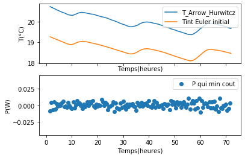

```
number of iterations:10001, cout_final = 0.011021163554501275 €
Time spent = 778.7668755054474
```

```python
def visualisation_arrow(T0, n_it, P_max, T_max, T_min, comparaison=True):
    res = arrow_hurwicz(fun, grad_fun, lambda T:-contrainte(T, P_max, T_max, T_min), lambda T:-grad_contrainte(T), np.array([20 for _ in range(N+1)]), 0.1, 0.1, max_iter = n_it)
    fig, (ax1, ax2) = plt.subplots(2, sharex=True)
    ax1.plot(T[2:], res[0], label='T_Arrow_Hurwitcz')
    if comparaison:
        ax1.plot(T[2:], Euler_explicit(myfunc, a_1[0], a_1[1], a_1[2], shift=2), label='Tint Euler initial')
    ax1.set_xlabel('Temps(heures)')
    ax1.set_ylabel('T(°C)')
    ax1.legend(loc='upper right')
    ax2.scatter(T[2:-1], P(res[0]), label = 'P qui min cout')
    ax2.set_xlabel('Temps(heures)')
    ax2.set_ylabel('P(W)')
    ax2.legend(loc='upper right')
    plt.show()
    print(f'number of iterations:{res[1]}, cout_final = {fun(res[0])} €')

start_arrow = time.time()
visualisation_arrow(np.array([20 for _ in range(N+1)]), 10000, P_max, T_max, T_min)
end_arrow = time.time()
print(f'Time spent = {end_arrow - start_arrow}')
```

On obtient donc, via **arrow hurwitcz a pas constant**, un profil de température optimal pour nos contraintes qui respecte bien la dynamique du système (avec simplement une condition initiale différente). On note que par soucis de temps d'exécution on a imposé un nombre d'itérations maximal assez faible (de 10 000) mais que l'algorithme paraît bien converger vers la solution optimale. L'algorithme s'arrête de tourner une fois les itérations réalisées et non par quasi-annulation du gradient du lagrangien car il faudrait pour cela une puissance de calcul plus importante vu la lenteur de l'implémentation considérée. On voit aussi que le coût final est quasiment nul, ce qui correspond à nos attentes, cependant on voit des termes de puissance négatifs, une de nos contraintes semble ne pas être adéquatement respectées... On imposera des contraintes plus restreignantes par la suite, maintenant qu'on est a peu près sûr que notre algorithme tourne correctement.

On utilise maintenant la **méthode minimize** de scipy. On voit que la courbe de température trouvée ressemble fortement à celle trouvée par arrow-hurwitcz ppour les mêmes conditions initiales, bien que scipy tourne **bien** plus rapidement et pour un résultat quand même plus "lisse". On voit bien que la dynamique est respectée, et que le coût ainsi que le profil de puissance obtenus sont bien voisins de 0 et du vecteur nul. Notre minimisation fonctionne bien pour des contraintes "douces" qui n'imposent pas l'utilisation du chauffage électrique, ce qui donné une fonction coût nulle.

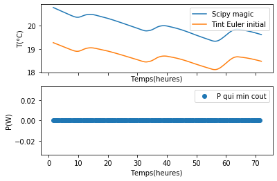

```
Sucess:True, number of iterations:20, cout_final = -8.138066395595343e-10 €
Time spent 1.4502322673797607
```

```python
def visualisation_scipy(T0, method, P_max, T_max, T_min, comparaison):
    res = optimize.minimize(fun, T0, method = method , bounds = [(0, np.inf) for _ in range(N+1)], constraints = {'type':'ineq', 'fun':lambda T:contrainte(T, P_max, T_max, T_min)})
    fig, (ax1, ax2) = plt.subplots(2, sharex=True)
    ax1.plot(T[2:], res.x, label='Scipy magic')
    if comparaison:
        ax1.plot(T[2:], Euler_explicit(myfunc, a_1[0], a_1[1], a_1[2], shift=2), label='Tint Euler initial')
    ax1.set_xlabel('Temps(heures)')
    ax1.set_ylabel('T(°C)')
    ax1.legend(loc='upper right')
    ax2.scatter(T[2:-1], P(res.x), label = 'P qui min cout')
    ax2.set_xlabel('Temps(heures)')
    ax2.set_ylabel('P(W)')
    ax2.legend(loc='upper right')
    plt.show()
    print(f'Sucess:{res.success}, number of iterations:{res.nit}, cout_final = {fun(res.x)} €')

start_scipy = time.time()
visualisation_scipy(np.array([20 for _ in range(N+1)]), 'SLSQP', P_max, T_max, T_min, True)
end_scipy = time.time()
print(f'Time spent {end_scipy - start_scipy}')
```

#### Imposons des contraintes réelles

Imaginons que les habitants de notre maison sont très stricte au niveau de la température intérieure, ils souhaitent que la température intérieure reste entre 21,5°C et 22°C. Regardons les profils de puissance que nous donne nos algorithmes de minimisation.

```python
#Nouvelles contraintes
Tmax2, Tmin2, Pmax2 = 22, 21.5, 750
T_max2 = np.array([Tmax2 for _ in range(N+1)])
T_min2 = np.array([Tmin2 for _ in range(N+1)])
P_max2 = np.array([Pmax2 for _ in range(N)])
```

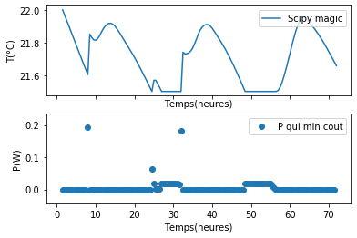

```
Sucess:True, number of iterations:89, cout_final = 0.109626738584148 €
```

```python
visualisation_scipy(np.array([22 for _ in range(N+1)]), 'SLSQP', P_max2, T_max2, T_min2, False)
```

L'algorithme nous donne donc quelque chose de très cohérent. La température intérieure suit sa dynamique naturelle de température sans chauffage qui dépend des conditions extérieures, jusqu'à l'activation de la contrainte au seuil de température minimale. Ensuite, le chauffage s'allume pour faire remonter la température. Et ainsi de suite.

Regardons maintenant les performances de notre Arrow-Hurwitcz a pas fixe. Il obtient aussi un profil de puissance qui respecte les contraintes et qui minimise le coût. En effet, le coût minimal obtenu est proche de celui obtenu avec scipy, bien que l'algorithme soit bien plus gourmand en temps d'exécution et en itérations.

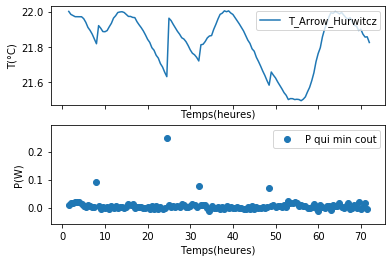

```
number of iterations:1001, cout_final = 0.13320367618274023 €
```

```python
visualisation_arrow(np.array([22 for _ in range(N+1)]), 1000, P_max2, T_max2, T_min2, comparaison=False)
```

# Etude avancée

## Question 1

On considère le cas d'un immeuble résidentiel composé de deux appartements, disposés l'un au dessus de l'autre, chaque appartement étant un cube de même longueur $l$, disposant d'un chauffage piloté collectivement, on essaie donc de minimiser le coût global. La démarche est similaire que pour le cas de la maison unique. La fonction objective à minimiser est: $$f(P_1,P_2, T_{int}^{1}, T_{int}^{2}) = \Delta t \sum^{N}_{k = 1}c_{k}(p_{k}^{1} + p_{k}^{2}) = \Delta t c'^{T}P \tag{15}$$

Avec $P_1$ et $P_2$ les profils de puissance dans chaque appartement, d'où P = $\begin{pmatrix} P1 \\ P2 \end{pmatrix}$ et $c'$ est un vecteur de taille 2N $\begin{pmatrix} c \\ c \end{pmatrix}$ (ou plutôt de taille 4N+2 avec des éléments nuls pour que les termes de températures n'aparaissent pas). Il faut cependant expliciter de nouveaux la dynamique de température du bâtiment, en effet il faudra considérer le terme de conduction de chaleur entre les deux appartements à travers le plafond du premier et le sol du deuxième. Ceci ammènera à un système d'équations différentielle couplées qui sera, comme précedemment, une contrainte. Il faudra aussi considérer les contraintes de température max, min et de puissance max pour chaque appartemment. Explicitons ce système d'équations différentielles:

$$ \begin{cases}C_{air}*\frac{\partial{T_{int}^{1}(t)}}{\partial{t}} = a_{ext}^{1}*(T_{ext}(t)-T_{int}^{1}(t)) + p_c^{1}(t) + I_s(t) * S^{1} * b + a_{int}(T_{int}^{2}(t) - T_{int}^{1}(t)) \\ C_{air}*\frac{\partial{T_{int}^{2}(t)}}{\partial{t}} = a_{ext}^{2}*(T_{ext}(t)-T_{int}^{2}(t)) + p_c^{2}(t) + I_s(t) * S^{2} * b + a_{int}(T_{int}^{1}(t) - T_{int}^{2}(t))\end{cases}$$

Revenons rapidement sur les quelques hypothèses effectuées. Le $a_{ext}^{2} = \frac{1}{R_{eq}^{2}}$ diffère d'un seul terme d'échange conducto-convectif avec l'extérieur à travers le plafond qu'il faut rajouter par rapport à $a_{ext}^{1}$. On considère $b^{1} = b^{2}$, qu'on note $b$. On a $a_{int}^1 = a_{int}^2 = \frac{\lambda_{plafond}*S_{plafond}}{e_{plafond}}$. On a de plus $S^2 = 3*l^2$ et $S^1 = 2*l^2$ car le premier appartement ne reçoit pas de lumière à travers le plafond et seulement deux murs à la fois peuvent être éclairés. On considère que les deux appartements ont la même taille, et donc le même volume et le même $C_{air}$.

Pour la résolution proprement dite, il suffit d'obtenir toutes les constantes qui nous intéressent, et mettre en place une méthode de résolution très proche de celle effectuée dans la partie II. On aura une fonction qui prend deux fois le nombre d'entrées, qui aura deux fois plus de contraintes (sachant que la contrainte de dynamique est légèrement modifiée par les échanges de chaleur inter-appartement). Au lieu de remplacer les expressions des puissances comme effectué précedemment en mettant toutes les expressions sous la forme de fonctions de la température, on pourra laisser la fonction coût sous la forme en (15) et garder les contraintes égalités à respecter sous la forme de deux contraintes inégalités opposées. On remprendra la formulation uniquement en température dans l'algorithme de décomposition/coordination.

Le cas de n appartements se traite d'une façon similaire, à ceci près que les n équations différentielles couplées ne seront pas toutes aussi similaire que les deux présentées ci-dessus car il faudra prendre en compte les échanges conductifs avec les voisins d'a côté mais aussi d'en haut et d'en bas. Sinon la fonction coût reste de la même forme, avec une décomposition en n sous-fonction utile pour la décomposition-coordination mise en place par la suite.

```python
#Définissons les constantes utiles pas définies avant...
a_ext_2 = a  #même coefficient que pour la maison unique W/K
a_ext_1 = (4/5)*a #4/5 des échanges de chaleur avec l'extérieur on considére que les murs et le plafond on la même resistance
S2 = S
S1 = 2*l**2
a_int = (1/5)*a
Tmax_mul1, Tmax_mul2 = 24, 22
Tmin_mul1, Tmin_mul2 = 22, 21  #pour que ça soit asymétrique
Pmax_mul1, Pmax_mul2 = 750, 750
cout_mul = np.concatenate((cout, cout, np.zeros(2*N+2))) #les vecteurs de température sont de taille N+1
N_mul = len(cout_mul)
T_max_mul1 = np.array([Tmax_mul1 for _ in range(N+1)])
T_max_mul2 = np.array([Tmax_mul2 for _ in range(N+1)])
T_min_mul1 = np.array([Tmin_mul1 for _ in range(N+1)])
T_min_mul2 = np.array([Tmin_mul2 for _ in range(N+1)])
P_max_mul1 = np.array([Pmax_mul1 for _ in range(N)])
P_max_mul2 = np.array([Pmax_mul2 for _ in range(N)])
A1 = np.array([[a_ext_1 + a_int - (c_air*l**3)/pas_temps if i==j else (c_air*l**3)/pas_temps if j==i+1 else 0 for j in range(N+1)] for i in range(N)])
A2 = np.array([[a_ext_2 + a_int - (c_air*l**3)/pas_temps if i==j else (c_air*l**3)/pas_temps if j==i+1 else 0 for j in range(N+1)] for i in range(N)])
```

```python
#Redéfinissons les fonctions utiles
def fun_mul(X):
    '''
    X = concatenation de P1,P2,T1,T2. Taille 4N+2.
    '''
    return pas_temps*np.dot(cout_mul, X)

def grad_fun_mul(X):
    return pas_temps*cout_mul

def Contrainte(X, P_max_mul1 = P_max_mul1, P_max_mul2 = P_max_mul2, T_max1 = T_max_mul1, T_max_mul2 = T_max_mul2, T_min_mul1 = T_min_mul1, T_min_mul2 = T_min_mul2):
    '''
    Le vecteur contrainte est assez gros du coup...
    '''
    P1, P2, T1, T2 = X[:N], X[N:2*N], X[2*N:3*N+1], X[3*N+1:4*N+2]
    c1 = P1 - P_max_mul1
    c2 = P2 - P_max_mul2
    c3 = T1 - T_max_mul1
    c4 = T_min_mul1 - T1
    c5 = T2 - T_max_mul2
    c6 = T_min_mul2 - T2
    c7 = P1  - (np.matmul(A1, T1) - Is*S1*b - a_ext_1*T_ext - a_int*T2[:-1])
    c7bis = np.matmul(A1, T1) - Is*S1*b - a_int*T2[:-1] - a_ext_1*T_ext - P1
    c8 = P2 - (np.matmul(A2, T2) - Is*S2*b - a_int*T1[:-1] - a_ext_2*T_ext)
    c8bis = np.matmul(A2, T2) - Is*S2*b - a_int*T1[:-1]- a_ext_2*T_ext - P2
    return np.concatenate((c1, c2, c3, c4, c5, c6, c7, c7bis, c8, c8bis))
```

```python
Pini, T10, T20 = np.array([0 for _ in range(N)]), np.array([Tmax_mul1  for _ in range(N+1)]), np.array([Tmax_mul2  for _ in range(N+1)])
X0 = np.concatenate((Pini, Pini, T10, T20 ))
start_cent = time.time()
res_mul = optimize.minimize(fun_mul, X0, method = 'SLSQP' , bounds = [(0, np.inf) for _ in range(4*N+2)], constraints = {'type':'ineq', 'fun':lambda X:-Contrainte(X)})
end_cent = time.time()
print(f'Time spent {end_cent - start_cent}')
```

```
Time spent 192.07393431663513
```

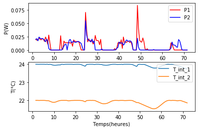

```
Sucess:True, number of iterations:68, cout_final = 0.32004522604194185 €
```

```python
fig, (axs1, axs2) = plt.subplots(2)
axs1.plot(T[2:-1], res_mul.x[0:N], label = "P1", c='r')
axs1.plot(T[2:-1], res_mul.x[N:2*N], label = "P2", c='b')
axs1.set_xlabel('Temps(heures)')
axs1.set_ylabel('P(W)')
axs1.legend(loc='upper right')
axs2.plot(T[2:], res_mul.x[2*N:3*N+1], label = 'T_int_1')
axs2.plot(T[2:], res_mul.x[3*N+1:4*N+2], label = 'T_int_2')
axs2.set_xlabel('Temps(heures)')
axs2.set_ylabel('T(°C)')
axs2.legend(loc='upper right')
plt.show()
print(f'Sucess:{res_mul.success}, number of iterations:{res_mul.nit}, cout_final = {fun_mul(res_mul.x)} €')
```

Bon, là notre super scipy semble un peu dépassé, sûrement à cause de l'expression **très lourde** des contraintes ou une erreur d'implémentation. Finalement, il aurait peut être fallu remplacer directement l'expression des puissances par celles liées aux températures pour que ça soit un peu moins lourd.

## Question 2

On cherche maintenant à distribuer les calculs. Il s'agit de reformuler le problème pour l'écrire sous la même forme que présentée en annexe.

$$ f(P_1,P_2, T_{int}^{1}, T_{int}^{2}) = \Delta t \sum^{N}_{k = 1}c_{k}(p_{k}^{1} + p_{k}^{2}) = f_1(T_1) + f_2(T_2) $$

.

On utilise les expressions des puissances reliées aux températures via les équations différentielle couplées. $ f_1(T_1) = A^{1}T_1 -I_{s}*S^1*b-a^{1}T_{ext}$, $ f_2(T_2) = A^{2}T_2 -I_{s}*S^2*b-a^{2}T_{ext}$, en effet les termes croisés dépendant de $a_{int}$ disparaissent lorsqu'on somme les deux profils de puissance. Nos contraintes s'expriment maintenant en fonction de $T_1$ et $T_2$ uniquement, comme précedemment dans la partie II et on peut décomposer en n sous-problème à l'échelle de chaque appartement. On note que même dans le cas de n appartements, les termes croisés de conduction interne au bâtiment disparaissent tous (c'est de la chaleur qui reste à l'intérieur du bâtiment). On note finalement que il y a des termes de résistance int et résistance ext qui sont différents pour chaque appartement donc ce n'est pas exactement le même problème n fois.

## Question 3

On implémente la résolution algorithmique pour deux appartements qu'on comparera avec les résultats trouvés dans la question 1.

```python
#Il faut changer les matrices pour enlever le terme en aint
AA1 = np.array([[a_ext_1 - (c_air*l**3)/pas_temps if i==j else (c_air*l**3)/pas_temps if j==i+1 else 0 for j in range(N+1)] for i in range(N)])
AA2 = np.array([[a_ext_2 - (c_air*l**3)/pas_temps if i==j else (c_air*l**3)/pas_temps if j==i+1 else 0 for j in range(N+1)] for i in range(N)])
def P1(T):
    '''
    Ca peut paraître long de définir toutes ces fonctions mais c'est utile pour tout tracer après résolution
    '''
    return np.matmul(AA1, T) - Is*S1*b - a_ext_1*T_ext
def P2(T):
    return np.matmul(AA2, T) - Is*S2*b - a_ext_2*T_ext

def f1(T1):
    return pas_temps*np.dot(cout, P1(T1))
def f2(T2):
    return pas_temps*np.dot(cout, P2(T2))
def grad_f1(T1):
    return pas_temps*np.matmul(AA1.transpose(), cout)
def grad_f2(T2):
    return pas_temps*np.matmul(AA2.transpose(), cout)

def contrainte_1(T, P_max = P_max_mul1, T_max = T_max_mul1, T_min = T_min_mul1):
    C1, C2, C3, C4 = P1(T), P_max - P1(T), T_max - T , T - T_min
    C = np.concatenate((C1, C2, C3, C4))
    return -C  #<=0

def contrainte_2(T, P_max = P_max_mul2, T_max = T_max_mul2, T_min = T_min_mul2):
    C1, C2, C3, C4 = P2(T), P_max - P2(T), T_max - T , T - T_min
    C = np.concatenate((C1, C2, C3, C4))
    return -C

def grad_contrainte_1(T):
    G1, G2, G3, G4 = AA1, -AA1, -np.eye(N+1, N+1), np.eye(N+1, N+1)
    G = np.concatenate((G1, G2, G3, G4))
    return -G

def grad_contrainte_2(T):
    G1, G2, G3, G4 = AA2, -AA2, -np.eye(N+1, N+1), np.eye(N+1, N+1)
    G = np.concatenate((G1, G2, G3, G4))
    return -G
```

```python
#decomposition/coordination
def decomposition(lambda0, rho, T0, method, liste_fonctions, liste_contraintes, max_iter, tol = 1e-3):
    lambdk = lambda0
    solutions = [[] for _ in range(max_iter+1)]
    compteur = 0
    while compteur <= max_iter:
        for i in range(len(liste_fonctions)):
            funky = lambda X: liste_fonctions[i](X) + np.dot(lambdk, liste_contraintes[i](X))
            res = optimize.minimize(funky, T0, method = method , bounds = [(0, np.inf) for _ in range(N+1)], constraints = {'type':'ineq', 'fun':lambda T:-liste_contraintes[i](T)})
            solutions[compteur].append(res.x)
        somme_contrainte = np.array([liste_contraintes[p](solutions[compteur][p]) for p in range(len(liste_contraintes))])
        lambdk1 = np.array([max(0, lambdk[i] + rho*sum([somme_contrainte[n,i] for n in range(len(liste_contraintes))])) for i in range(len(lambdk))])
        if np.linalg.norm(lambdk1 - lambdk) <= tol:
            return solutions[compteur]
        else:
            lambdk = lambdk1
            compteur += 1
    return solutions, compteur
```

```python
lambda0, T0 = np.array([0.1 for _ in range(4*N+2)]), np.array([22 for _ in range(N+1)])
start_decompo = time.time()
solutions, compteur = decomposition(lambda0, 0.1, T0, 'SLSQP', [f1, f2], [contrainte_1, contrainte_2], 10)
end_decompo = time.time()
print(f'Time_spent = {end_decompo - start_decompo}')
```

```
Time_spent = 85.32028484344482
```

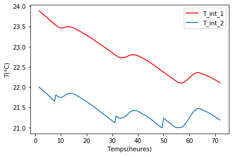

```
coût final = 0.06307407475561856, n_ut = 11
```

```python
plt.plot(T[2:], solutions[-1][0], c='r', label = 'T_int_1')
plt.plot(T[2:], solutions[-1][1], label = 'T_int_2')
plt.xlabel('Temps(heures)')
plt.ylabel('T(°C)')
plt.legend()
plt.show()
print(f'coût final = {f1(solutions[-1][0]) + f2(solutions[-1][1])}, n_ut = {compteur}')
```

L'algorithme décomposition coordination marche assez bien, les profils de température obtenus sont cohérents, ils respectent les contraintes. Nous pouvons comparer le temps d'exécution avec l'algorithme centralisé ce qui nous donne une bonne indication des performances comparées. L'algorithme décomposition donne un profil de température beaucoup plus cohérents en 85s contre 192s. Il gagne donc en temps d'exécution et en cohérence vis à vis du résultat cherché.